# Case Study

Nitrogen Source Optimization for Cellulase Production by *Penicillium funiculosum*, using a Sequential Experimental Design Methodology and the Desirability Function

## The Chosen Article

[Maeda, R.N., da Silva, M.M.P., Santa Anna, L.M.M. et al. Nitrogen Source Optimization for Cellulase Production by *Penicillium funiculosum*, using a Sequential Experimental Design Methodology and the Desirability Function. Appl Biochem Biotechnol 161, 411–422 (2010)](https://link.springer.com/content/pdf/10.1007/s12010-009-8875-6.pdf?pdf=button)

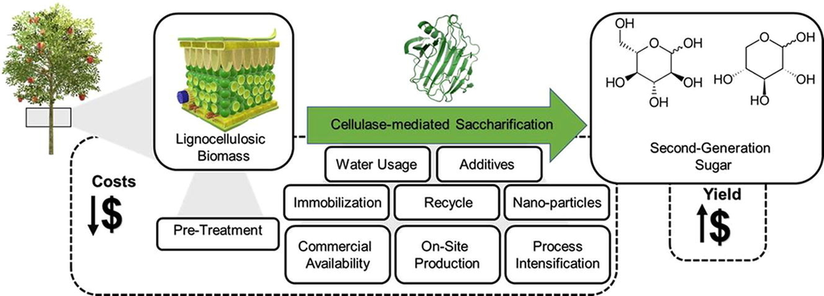

Second-generation ethanol production. Source: [https://doi.org/10.1016/j.cej.2022.138690](https://www.sciencedirect.com/science/article/abs/pii/S1385894722041717?via%3Dihub)

## Experimental Methods

Three distinct methods were employed to quantify cellulase activity, serving as the variables under consideration for optimization:

- Filter Paper Assay (FPase)
- Carboxymethylcellulose Assay (CMCase)
- Cellobiose Assay (𝛽-Glucosidase)

- Urea
- Ammonium Sulfate
- Peptone
- Yeast Extract

## Sequential Experimenta Design

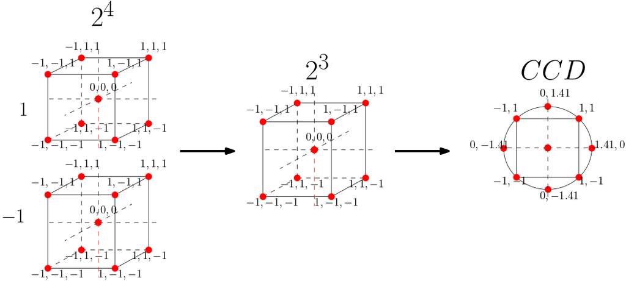

The sequential experimental design involves a series of meticulously crafted iterations, wherein each step entails the elimination of an insignificant variable.

# Factorial $2^4$

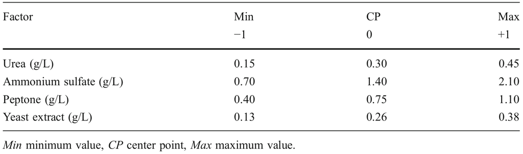

Levels for independent variables for the $2^4$ experimental design.

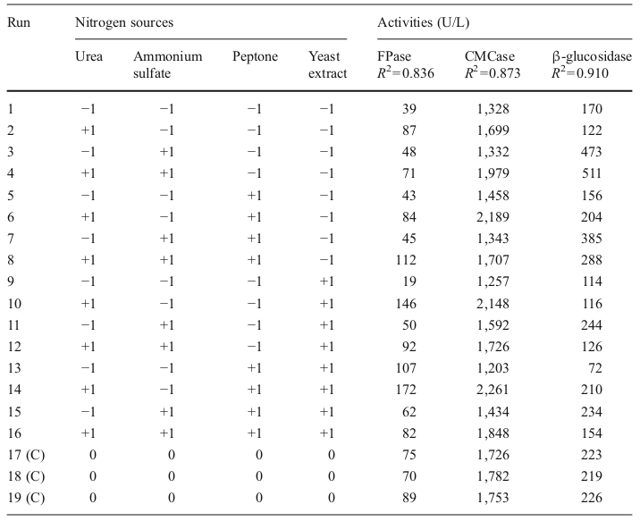

Experimental results of each run of the $2^4$ design.

# `explann` hands-on on $2^4$ design

A `python` package ([`explann`](https://github.com/properallan/explann/)) was developed to assist design and statistical analysis of experiments.

`TwoLevelFactorial` implements a generic $2^n$ factorial design, with $n$ variables defined as a dictionary containunt the variable name and range.

```python
from explann.doe import TwoLevelFactorial

f2b4 = TwoLevelFactorial(
    variables = {
        'U': (0.15, 0.45),
        'A': (0.70, 2.10),
        'P': (0.40, 1.10),
        'Y': (0.13, 0.38)
    },
    central_points=3
)
```

Once instantiated this class build the `doe` table, storage as an object attribute as a `pandas` `DataFrame`.

```python
f2b4.doe
```

| Index | U | A | P | Y |
| --- | --- | --- | --- | --- |
| 1 | -1.0 | -1.0 | -1.0 | -1.0 |
| 2 | 1.0 | -1.0 | -1.0 | -1.0 |
| 3 | -1.0 | 1.0 | -1.0 | -1.0 |
| 4 | 1.0 | 1.0 | -1.0 | -1.0 |
| 5 | -1.0 | -1.0 | 1.0 | -1.0 |
| 6 | 1.0 | -1.0 | 1.0 | -1.0 |
| 7 | -1.0 | 1.0 | 1.0 | -1.0 |
| 8 | 1.0 | 1.0 | 1.0 | -1.0 |
| 9 | -1.0 | -1.0 | -1.0 | 1.0 |
| 10 | 1.0 | -1.0 | -1.0 | 1.0 |
| 11 | -1.0 | 1.0 | -1.0 | 1.0 |
| 12 | 1.0 | 1.0 | -1.0 | 1.0 |
| 13 | -1.0 | -1.0 | 1.0 | 1.0 |
| 14 | 1.0 | -1.0 | 1.0 | 1.0 |
| 15 | -1.0 | 1.0 | 1.0 | 1.0 |
| 16 | 1.0 | 1.0 | 1.0 | 1.0 |
| 17 | 0.0 | 0.0 | 0.0 | 0.0 |
| 18 | 0.0 | 0.0 | 0.0 | 0.0 |
| 19 | 0.0 | 0.0 | 0.0 | 0.0 |

A table of the levels are also automaticly created.

```python
f2b4.levels
```

| Levels | U | A | P | Y |
| --- | --- | --- | --- | --- |
| -1.0 | 0.15 | 0.7 | 0.40 | 0.130 |
| 0.0 | 0.30 | 1.4 | 0.75 | 0.255 |
| 1.0 | 0.45 | 2.1 | 1.10 | 0.380 |

The `doe` table can be complemented with the response variables. For this task either `ImportString` or `ImportXLSX` can be used to load data.

```python
from explann.dataio import ImportString

f2b4_results = ImportString(data="""
F,CM,B
39,1.328,170
87,1.699,122
48,1.332,473
71,1.979,511
43,1.458,156
84,2.189,204
45,1.343,385
112,1.707,288
19,1.257,114
146,2.148,116
50,1.592,244
92,1.726,126
107,1.203,72
172,2.261,210
62,1.434,234
82,1.848,154
75,1.726,223
70,1.782,219
89,1.753,226
""",
delimiter=',')

f2b4_results.data
```

|  | F | CM | B |
| --- | --- | --- | --- |
| 1 | 39 | 1.328 | 170 |
| 2 | 87 | 1.699 | 122 |
| 3 | 48 | 1.332 | 473 |
| 4 | 71 | 1.979 | 511 |
| 5 | 43 | 1.458 | 156 |
| 6 | 84 | 2.189 | 204 |
| 7 | 45 | 1.343 | 385 |
| 8 | 112 | 1.707 | 288 |
| 9 | 19 | 1.257 | 114 |
| 10 | 146 | 2.148 | 116 |
| 11 | 50 | 1.592 | 244 |
| 12 | 92 | 1.726 | 126 |
| 13 | 107 | 1.203 | 72 |
| 14 | 172 | 2.261 | 210 |
| 15 | 62 | 1.434 | 234 |
| 16 | 82 | 1.848 | 154 |
| 17 | 75 | 1.726 | 223 |
| 18 | 70 | 1.782 | 219 |
| 19 | 89 | 1.753 | 226 |

The data is the merged with the `doe` table using `append_results` method.

```python
f2b4.append_results(results=f2b4_results.data)
f2b4.doe
```

| Index | U | A | P | Y | F | CM | B |
| --- | --- | --- | --- | --- | --- | --- | --- |
| 1 | -1.0 | -1.0 | -1.0 | -1.0 | 39 | 1.328 | 170 |
| 2 | 1.0 | -1.0 | -1.0 | -1.0 | 87 | 1.699 | 122 |
| 3 | -1.0 | 1.0 | -1.0 | -1.0 | 48 | 1.332 | 473 |
| 4 | 1.0 | 1.0 | -1.0 | -1.0 | 71 | 1.979 | 511 |
| 5 | -1.0 | -1.0 | 1.0 | -1.0 | 43 | 1.458 | 156 |
| 6 | 1.0 | -1.0 | 1.0 | -1.0 | 84 | 2.189 | 204 |
| 7 | -1.0 | 1.0 | 1.0 | -1.0 | 45 | 1.343 | 385 |
| 8 | 1.0 | 1.0 | 1.0 | -1.0 | 112 | 1.707 | 288 |
| 9 | -1.0 | -1.0 | -1.0 | 1.0 | 19 | 1.257 | 114 |
| 10 | 1.0 | -1.0 | -1.0 | 1.0 | 146 | 2.148 | 116 |
| 11 | -1.0 | 1.0 | -1.0 | 1.0 | 50 | 1.592 | 244 |
| 12 | 1.0 | 1.0 | -1.0 | 1.0 | 92 | 1.726 | 126 |
| 13 | -1.0 | -1.0 | 1.0 | 1.0 | 107 | 1.203 | 72 |
| 14 | 1.0 | -1.0 | 1.0 | 1.0 | 172 | 2.261 | 210 |
| 15 | -1.0 | 1.0 | 1.0 | 1.0 | 62 | 1.434 | 234 |
| 16 | 1.0 | 1.0 | 1.0 | 1.0 | 82 | 1.848 | 154 |
| 17 | 0.0 | 0.0 | 0.0 | 0.0 | 75 | 1.726 | 223 |
| 18 | 0.0 | 0.0 | 0.0 | 0.0 | 70 | 1.782 | 219 |
| 19 | 0.0 | 0.0 | 0.0 | 0.0 | 89 | 1.753 | 226 |

This experimental planning can be easily saved in `.xlsx` format. `doe` raw data is stored in the first sheet and the levels data is stored in a separate sheet named `levels`.

```python
f2b4.save_excel('../../data/f2b4.xlsx')
```

The `ImporXLSX` assist the import of data from excel file, this could be filled by hand or generated in `explann` as described above.

```python
from explann.dataio import ImportXLSX

f2b4_from_excel = ImportXLSX(
    path = '../../data/f2b4.xlsx',
    levels_sheet = 'levels'
)

f2b4_from_excel.data
```

|  | Index | U | A | P | Y | F | CM | B |
| --- | --- | --- | --- | --- | --- | --- | --- | --- |
| 1 | 1 | -1 | -1 | -1 | -1 | 39 | 1.328 | 170 |
| 2 | 2 | 1 | -1 | -1 | -1 | 87 | 1.699 | 122 |
| 3 | 3 | -1 | 1 | -1 | -1 | 48 | 1.332 | 473 |
| 4 | 4 | 1 | 1 | -1 | -1 | 71 | 1.979 | 511 |
| 5 | 5 | -1 | -1 | 1 | -1 | 43 | 1.458 | 156 |
| 6 | 6 | 1 | -1 | 1 | -1 | 84 | 2.189 | 204 |
| 7 | 7 | -1 | 1 | 1 | -1 | 45 | 1.343 | 385 |
| 8 | 8 | 1 | 1 | 1 | -1 | 112 | 1.707 | 288 |
| 9 | 9 | -1 | -1 | -1 | 1 | 19 | 1.257 | 114 |
| 10 | 10 | 1 | -1 | -1 | 1 | 146 | 2.148 | 116 |
| 11 | 11 | -1 | 1 | -1 | 1 | 50 | 1.592 | 244 |
| 12 | 12 | 1 | 1 | -1 | 1 | 92 | 1.726 | 126 |
| 13 | 13 | -1 | -1 | 1 | 1 | 107 | 1.203 | 72 |
| 14 | 14 | 1 | -1 | 1 | 1 | 172 | 2.261 | 210 |
| 15 | 15 | -1 | 1 | 1 | 1 | 62 | 1.434 | 234 |
| 16 | 16 | 1 | 1 | 1 | 1 | 82 | 1.848 | 154 |
| 17 | 17 | 0 | 0 | 0 | 0 | 75 | 1.726 | 223 |
| 18 | 18 | 0 | 0 | 0 | 0 | 70 | 1.782 | 219 |
| 19 | 19 | 0 | 0 | 0 | 0 | 89 | 1.753 | 226 |

If the `levels_sheet` argument is passed, the loaded object will contain an aditional table with the levels parsed.

```python
f2b4_from_excel.parsed_data
```

|  | Index | U | A | P | Y | F | CM | B |
| --- | --- | --- | --- | --- | --- | --- | --- | --- |
| 1 | 1 | 0.45 | 0.7 | 0.40 | 0.130 | 39 | 1.328 | 170 |
| 2 | 2 | 0.15 | 2.1 | 0.40 | 0.130 | 87 | 1.699 | 122 |
| 3 | 3 | 0.45 | 2.1 | 0.40 | 0.130 | 48 | 1.332 | 473 |
| 4 | 4 | 0.15 | 0.7 | 1.10 | 0.130 | 71 | 1.979 | 511 |
| 5 | 5 | 0.45 | 0.7 | 1.10 | 0.130 | 43 | 1.458 | 156 |
| 6 | 6 | 0.15 | 2.1 | 1.10 | 0.130 | 84 | 2.189 | 204 |
| 7 | 7 | 0.45 | 2.1 | 1.10 | 0.130 | 45 | 1.343 | 385 |
| 8 | 8 | 0.15 | 0.7 | 0.40 | 0.380 | 112 | 1.707 | 288 |
| 9 | 9 | 0.45 | 0.7 | 0.40 | 0.380 | 19 | 1.257 | 114 |
| 10 | 10 | 0.15 | 2.1 | 0.40 | 0.380 | 146 | 2.148 | 116 |
| 11 | 11 | 0.45 | 2.1 | 0.40 | 0.380 | 50 | 1.592 | 244 |
| 12 | 12 | 0.15 | 0.7 | 1.10 | 0.380 | 92 | 1.726 | 126 |
| 13 | 13 | 0.45 | 0.7 | 1.10 | 0.380 | 107 | 1.203 | 72 |
| 14 | 14 | 0.15 | 2.1 | 1.10 | 0.380 | 172 | 2.261 | 210 |
| 15 | 15 | 0.45 | 2.1 | 1.10 | 0.380 | 62 | 1.434 | 234 |
| 16 | 16 | 0.30 | 1.4 | 0.75 | 0.255 | 82 | 1.848 | 154 |
| 17 | 17 | 0.30 | 1.4 | 0.75 | 0.255 | 75 | 1.726 | 223 |
| 18 | 18 | 0.30 | 1.4 | 0.75 | 0.255 | 70 | 1.782 | 219 |
| 19 | 19 | 0.00 | 0.0 | 0.00 | 0.000 | 89 | 1.753 | 226 |

We can now use the data to build our factorial model. The `functions` attribute is a dictionary, the keys are funcion names, and the values are function equations, the syntax follows [`patsy`](https://patsy.readthedocs.io/en/latest/) stardadization. Here `U * A * P * Y` stands for all interaction terms between the 4 variables

```python
from explann.models import FactorialModel

fm2b4 = FactorialModel(
    data = f2b4_from_excel.data,
    functions = {
        "Fso"  : "F ~ U * A * P * Y + I(U**2) + I(A**2) + I(P**2) + I(Y**2)",
        "CMso" : "CM ~ U * A * P * Y + I(U**2) + I(A**2) + I(P**2) + I(Y**2)",
        "Bso"  : "B ~ U * A * P * Y + I(U**2) + I(A**2) + I(P**2) + I(Y**2)",
        "F"  : "F ~ U * A * P * Y",
        "CM" : "CM ~ U * A * P * Y",
        "B"  : "B ~ U * A * P * Y"}
)
```

The object fm2b4 stores all the filted models(Ordinary Least Squares) listed in `functions`, any given model can be retriev by indexing by function name.

```python
fm2b4['F']
```

```
<statsmodels.regression.linear_model.RegressionResultsWrapper at 0x7fcd1570edf0>
```

An overview of the results can be viewd using the `summary` method. The method accepts also a given funtion name as argument, if `None` is passed a dictionary of summary() is returned.

```python
fm2b4.summary()
```

```
{'Fso': <class 'statsmodels.iolib.summary.Summary'>
 """
                             OLS Regression Results
 ==============================================================================
 Dep. Variable:                      F   R-squared:                       0.992
 Model:                            OLS   Adj. R-squared:                  0.931
 Method:                 Least Squares   F-statistic:                     16.16
 Date:                Wed, 16 Aug 2023   Prob (F-statistic):             0.0598
 Time:                        19:16:43   Log-Likelihood:                -49.032
 No. Observations:                  19   AIC:                             132.1
 Df Residuals:                       2   BIC:                             148.1
 Df Model:                          16
 Covariance Type:            nonrobust
 ==============================================================================
                  coef    std err          t      P>|t|      [0.025      0.975]
 ------------------------------------------------------------------------------
 Intercept     78.0000      5.686     13.717      0.005      53.534     102.466
 U             27.0625      2.462     10.991      0.008      16.468      37.657
 A             -8.4375      2.462     -3.427      0.076     -19.032       2.157
 U:A           -8.0625      2.462     -3.274      0.082     -18.657       2.532
 P              9.6875      2.462      3.934      0.059      -0.907      20.282
 U:P           -2.9375      2.462     -1.193      0.355     -13.532       7.657
 A:P           -4.6875      2.462     -1.904      0.197     -15.282       5.907
 U:A:P          5.6875      2.462      2.310      0.147      -4.907      16.282
 Y             12.5625      2.462      5.102      0.036       1.968      23.157
 U:Y            4.6875      2.462      1.904      0.197      -5.907      15.282
 A:Y          -11.3125      2.462     -4.594      0.044     -21.907      -0.718
 U:A:Y         -8.1875      2.462     -3.325      0.080     -18.782       2.407
 P:Y            4.8125      2.462      1.955      0.190      -5.782      15.407
 U:P:Y         -7.5625      2.462     -3.071      0.092     -18.157       3.032
 A:P:Y         -9.3125      2.462     -3.782      0.063     -19.907       1.282
 U:A:P:Y       -0.6875      2.462     -0.279      0.806     -11.282       9.907
 I(U ** 2)      0.1719      1.549      0.111      0.922      -6.493       6.837
 I(A ** 2)      0.1719      1.549      0.111      0.922      -6.493       6.837
 I(P ** 2)      0.1719      1.549      0.111      0.922      -6.493       6.837
 I(Y ** 2)      0.1719      1.549      0.111      0.922      -6.493       6.837
 ==============================================================================
 Omnibus:                       19.262   Durbin-Watson:                   2.036
 Prob(Omnibus):                  0.000   Jarque-Bera (JB):               38.617
 Skew:                           1.278   Prob(JB):                     4.12e-09
```

[output cut: 218 more lines]

```
 U:A:Y        -17.4375      0.754    -23.122      0.000     -19.838     -15.037
 P:Y           19.5625      0.754     25.940      0.000      17.162      21.963
 U:P:Y         13.3125      0.754     17.652      0.000      10.912      15.713
 A:P:Y         21.5625      0.754     28.592      0.000      19.162      23.963
 U:A:P:Y        8.3125      0.754     11.022      0.002       5.912      10.713
 ==============================================================================
 Omnibus:                       31.293   Durbin-Watson:                   2.398
 Prob(Omnibus):                  0.000   Jarque-Bera (JB):               77.186
 Skew:                          -2.374   Prob(JB):                     1.73e-17
 Kurtosis:                      11.658   Cond. No.                         1.09
 ==============================================================================

 Notes:
 [1] Standard Errors assume that the covariance matrix of the errors is correctly specified.
 """}
```

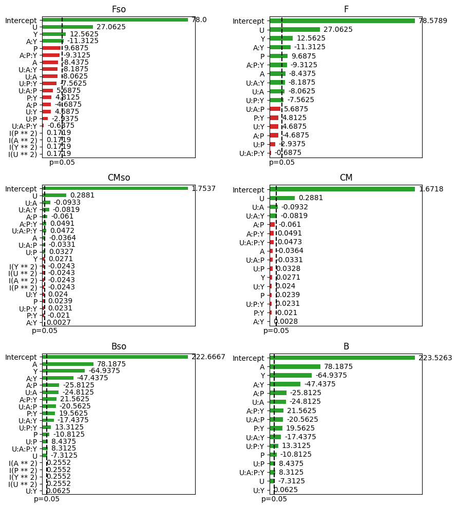

```python
from explann.plot import ParetoPlot

import matplotlib.pyplot as plt
fig, ax = plt.subplots(3,2, figsize=(9,10))
ax = ax.flatten()
pp_fm2b4 = ParetoPlot(fm2b4)

pp_fm2b4.plot(['Fso', 'F', 'CMso', 'CM' ,'Bso', 'B'], ax=ax)
plt.tight_layout()
```

```python
fm2b4.print_equation()
```

```
{'Fso': 'F = 78.0000 + 27.0625 * U + 12.5625 * Y - 11.3125 * AY',
 'CMso': 'CM = 1.7537 + 0.2881 * U - 0.0364 * A - 0.0933 * UA + 0.0327 * UP - 0.0610 * AP - 0.0331 * UAP - 0.0819 * UAY + 0.0491 * APY + 0.0472 * UAPY - 0.0243 * I(U ** 2) - 0.0243 * I(A ** 2) - 0.0243 * I(P ** 2) - 0.0243 * I(Y ** 2)',
 'Bso': 'B = 222.6667 - 7.3125 * U + 78.1875 * A - 24.8125 * UA - 10.8125 * P + 8.4375 * UP - 25.8125 * AP - 20.5625 * UAP - 64.9375 * Y - 47.4375 * AY - 17.4375 * UAY + 19.5625 * PY + 13.3125 * UPY + 21.5625 * APY + 8.3125 * UAPY',
 'F': 'F = 78.5789 + 27.0625 * U - 8.4375 * A - 8.0625 * UA + 9.6875 * P + 12.5625 * Y - 11.3125 * AY - 8.1875 * UAY - 7.5625 * UPY - 9.3125 * APY',
 'CM': 'CM = 1.6718 + 0.2881 * U - 0.0932 * UA - 0.0819 * UAY',
 'B': 'B = 223.5263 - 7.3125 * U + 78.1875 * A - 24.8125 * UA - 10.8125 * P + 8.4375 * UP - 25.8125 * AP - 20.5625 * UAP - 64.9375 * Y - 47.4375 * AY - 17.4375 * UAY + 19.5625 * PY + 13.3125 * UPY + 21.5625 * APY + 8.3125 * UAPY'}
```

`build_significant_models` get the models with only significant terms withing a significance value $\alpha$.

```python
sig_fm2b4=fm2b4.build_significant_models(alpha=0.05)
sig_fm2b4.summary()
```

```
{'Fso': <class 'statsmodels.iolib.summary.Summary'>
 """
                             OLS Regression Results
 ==============================================================================
 Dep. Variable:                      F   R-squared:                       0.644
 Model:                            OLS   Adj. R-squared:                  0.573
 Method:                 Least Squares   F-statistic:                     9.063
 Date:                Wed, 16 Aug 2023   Prob (F-statistic):            0.00115
 Time:                        19:16:45   Log-Likelihood:                -85.472
 No. Observations:                  19   AIC:                             178.9
 Df Residuals:                      15   BIC:                             182.7
 Df Model:                           3
 Covariance Type:            nonrobust
 ==============================================================================
                  coef    std err          t      P>|t|      [0.025      0.975]
 ------------------------------------------------------------------------------
 Intercept     78.5789      5.616     13.993      0.000      66.609      90.549
 U             27.0625      6.120      4.422      0.000      14.019      40.106
 Y             12.5625      6.120      2.053      0.058      -0.481      25.606
 A:Y          -11.3125      6.120     -1.849      0.084     -24.356       1.731
 ==============================================================================
 Omnibus:                        3.592   Durbin-Watson:                   2.130
 Prob(Omnibus):                  0.166   Jarque-Bera (JB):                1.637
 Skew:                          -0.592   Prob(JB):                        0.441
 Kurtosis:                       3.815   Cond. No.                         1.09
 ==============================================================================

 Notes:
 [1] Standard Errors assume that the covariance matrix of the errors is correctly specified.
 """,
 'CMso': <class 'statsmodels.iolib.summary.Summary'>
 """
                             OLS Regression Results
 ==============================================================================
 Dep. Variable:                     CM   R-squared:                       0.974
 Model:                            OLS   Adj. R-squared:                  0.942
 Method:                 Least Squares   F-statistic:                     30.17
 Date:                Wed, 16 Aug 2023   Prob (F-statistic):           2.87e-05
 Time:                        19:16:45   Log-Likelihood:                 29.977
 No. Observations:                  19   AIC:                            -37.95
```

[output cut: 165 more lines]

```
 U:A:Y        -17.4375      0.654    -26.669      0.000     -19.253     -15.622
 P:Y           19.5625      0.654     29.919      0.000      17.747      21.378
 U:P:Y         13.3125      0.654     20.360      0.000      11.497      15.128
 A:P:Y         21.5625      0.654     32.977      0.000      19.747      23.378
 U:A:P:Y        8.3125      0.654     12.713      0.000       6.497      10.128
 ==============================================================================
 Omnibus:                       31.153   Durbin-Watson:                   2.404
 Prob(Omnibus):                  0.000   Jarque-Bera (JB):               76.327
 Skew:                          -2.365   Prob(JB):                     2.67e-17
 Kurtosis:                      11.605   Cond. No.                         1.09
 ==============================================================================

 Notes:
 [1] Standard Errors assume that the covariance matrix of the errors is correctly specified.
 """}
```

```python
sig_fm2b4.anova('F')
```

|  | df | sum_sq | mean_sq | F | PR(>F) |
| --- | --- | --- | --- | --- | --- |
| U | 1.0 | 11718.062500 | 11718.062500 | 54.585296 | 0.000042 |
| A | 1.0 | 1139.062500 | 1139.062500 | 5.306002 | 0.046733 |
| U:A | 1.0 | 1040.062500 | 1040.062500 | 4.844838 | 0.055241 |
| P | 1.0 | 1501.562500 | 1501.562500 | 6.994606 | 0.026706 |
| Y | 1.0 | 2525.062500 | 2525.062500 | 11.762293 | 0.007513 |
| A:Y | 1.0 | 2047.562500 | 2047.562500 | 9.537994 | 0.012964 |
| U:A:Y | 1.0 | 1072.562500 | 1072.562500 | 4.996231 | 0.052249 |
| U:P:Y | 1.0 | 915.062500 | 915.062500 | 4.262561 | 0.068965 |
| A:P:Y | 1.0 | 1387.562500 | 1387.562500 | 6.463569 | 0.031588 |
| Residual | 9.0 | 1932.069079 | 214.674342 | NaN | NaN |

# Factorial $2^3$

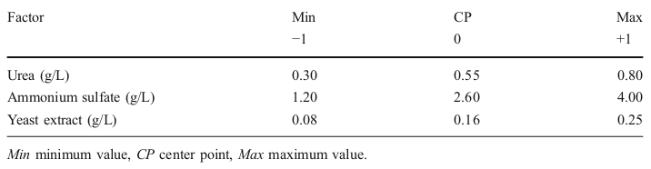

Levels for factorial $2^3$ experimental design.

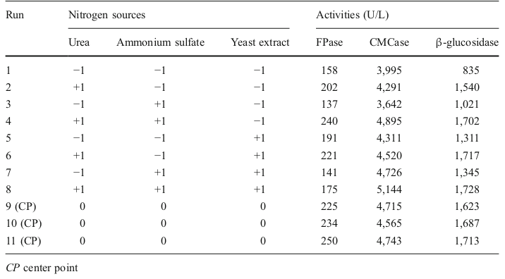

Experimental results for factorial $2^3$

# building a model with `explann`

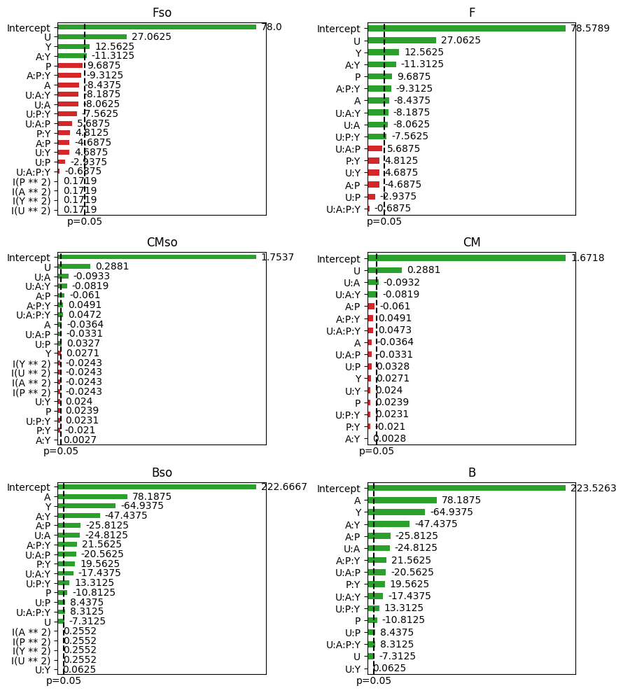

```python
from explann.doe import TwoLevelFactorial
from explann.models import FactorialModel
from explann.dataio import ImportString, ImportXLSX
from explann.plot import ParetoPlot
import matplotlib.pyplot as plt


f2b3 = TwoLevelFactorial(
    variables = {
        'U': (0.3, 0.8),
        'A': (1.20, 4.00),
        'Y': (0.08, 0.25)
    },
    central_points=3
)

f2b3_results = ImportString(
    data=
    """F,CM,B
    158,3995,835
    202,4291,1540
    137,3642,1021
    240,4895,1702
    191,4311,1311
    221,4520,1717
    141,4726,1345
    175,5144,1728
    225,4715,1623
    234,4565,1687
    250,4743,1713
    """,
    delimiter=',')

f2b3.append_results(results=f2b3_results.data)

f2b3.save_excel('../../data/f2b3.xlsx')

f2b3_from_excel = ImportXLSX(
    path = '../../data/f2b3.xlsx',
    levels_sheet = 'levels'
)


fm_f2b3 = FactorialModel(
    data = f2b3_from_excel.data,
    functions = {
        "Fso"  : "F ~ U * A * Y + I(U**2) + I(A**2) + I(Y**2)",
        "CMso" : "CM ~ U * A * Y + I(U**2) + I(A**2) + I(Y**2)",
        "Bso"  : "B ~ U * A * Y + I(U**2) + I(A**2)  + I(Y**2)",
        "F"  : "F ~ U * A * Y",
        "CM" : "CM ~ U * A * Y",
        "B"  : "B ~ U * A * Y"}
)

pp_f2b3 = ParetoPlot(fm_f2b3)

fig, ax = plt.subplots(3,2, figsize=(9,10))

pp_fm2b4.plot(['Fso', 'F', 'CMso', 'CM' ,'Bso', 'B'], ax=ax)
plt.tight_layout()
```

# Central Composite Design

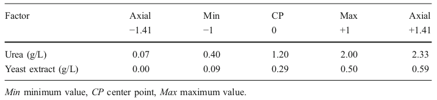

Levels for central composite experimental design.

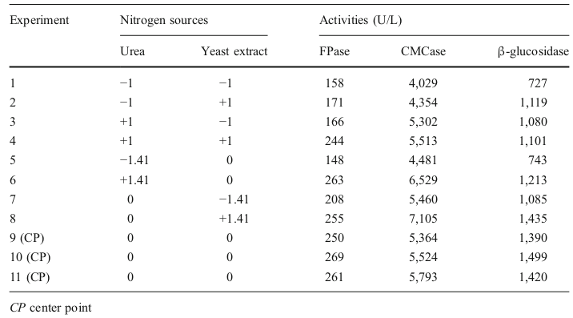

Experimental results for ccd.

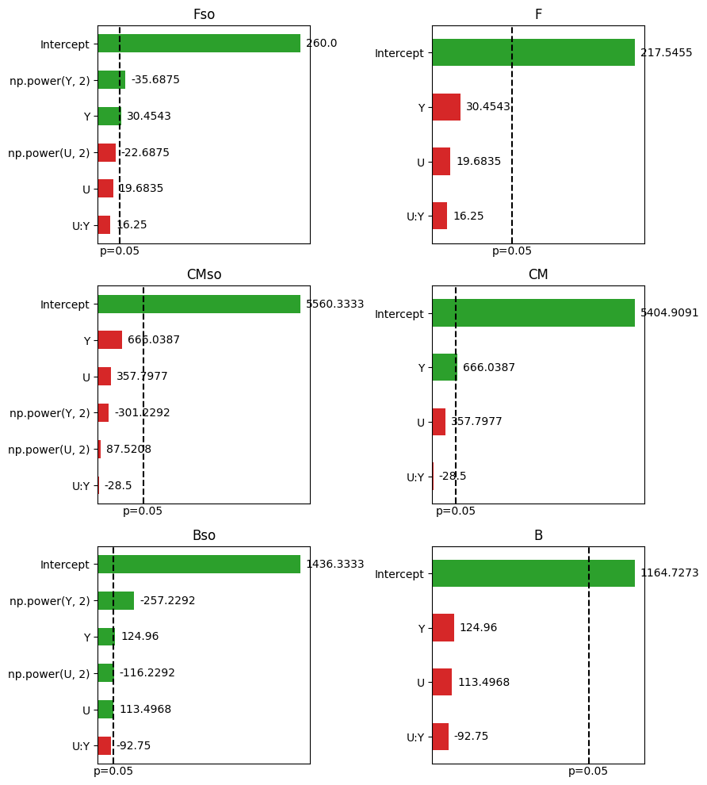

```python
from explann.doe import CentralCompositeDesign
from explann.models import FactorialModel
from explann.dataio import ImportString, ImportXLSX
from explann.plot import ParetoPlot
import matplotlib.pyplot as plt


ccd = CentralCompositeDesign(
    variables = {
        'U': (0.07, 2.33),
        'Y': (0.00, 0.59)
    },
    center=(0,3)
)

ccd_results = ImportString(
    data=
    """F,CM,B
    158,4029,727
    171,4354,1119
    166,5302,1080
    244,5513,1101
    208,5460,1085
    255,7105,1435
    148,4481,743
    263,6529,1213
    250,5364,1390
    269,5524,1499
    261,5793,1420
    """,
    delimiter=',')

ccd.append_results(results=ccd_results.data)

ccd.save_excel('../../data/ccd.xlsx')

ccd_from_excel = ImportXLSX(
    path = '../../data/ccd.xlsx',
    levels_sheet = 'levels'
)


fm_ccd = FactorialModel(
    data = ccd_from_excel.data,
    functions = {
        #"Fso"  : "F ~ U * Y + I(U**2) + I(Y**2)",
        #"CMso" : "CM ~ U *  Y + I(U**2) + I(Y**2)",
        #"Bso"  : "B ~ U * Y + I(U**2) + I(Y**2)",
        "Fso"  : "F ~ U * Y + np.power(U,2) + np.power(Y,2)",
        "CMso" : "CM ~ U *  Y + np.power(U,2) + np.power(Y,2)",
        "Bso"  : "B ~ U * Y + np.power(U,2) + np.power(Y,2)",
        "F"  : "F ~ U * Y",
        "CM" : "CM ~ U * Y",
        "B"  : "B ~ U * Y"},
    levels = ccd_from_excel.levels,
)

pp_ccd = ParetoPlot(fm_ccd)

fig, ax = plt.subplots(3,2, figsize=(9,10))

pp_ccd.plot(['Fso', 'F', 'CMso', 'CM' ,'Bso', 'B'], ax=ax)
plt.tight_layout()
```

```python
import matplotlib.pyplot as plt
import numpy as np
import pandas as pd
from matplotlib import cm # for a scatter plot
from mpl_toolkits.mplot3d import Axes3D

def plot_surface(x, y, z, model, n_pts=10, other_params={}, labels:dict=None, ax=None, cmap='viridis', scaled=False):
    name_z = z #'Fso'
    name_x = x #'U'
    name_y = y #'Y'
    n_pts = 10
    if not scaled:
        X = np.linspace( model.data[name_x].min(), model.data[name_x].max(), n_pts)
        Y = np.linspace( model.data[name_y].min(), model.data[name_y].max(), n_pts)
    else:
        X = np.linspace( model.levels[name_x].min(), model.levels[name_x].max(), n_pts)
        Y = np.linspace( model.levels[name_y].min(), model.levels[name_y].max(), n_pts)

    x, y = np.meshgrid(X, Y)

    try:
        variables = pd.DataFrame({name_x:x.ravel(), name_y:y.ravel(), **other_params})
    except:
        variables = pd.DataFrame([{name_x:x.ravel(), name_y:y.ravel(), **other_params}])

    if not scaled:
        z = model.predict(name_z, variables).values.reshape(x.shape)
    else:
        z = model.predict_rescaled(name_z, variables).values.reshape(x.shape)

    if ax is None:
        fig, ax = plt.subplots(figsize=(6,6),subplot_kw={"projection": "3d"})
    else:
        fig = plt.gcf()
    ax.set_box_aspect(None, zoom=0.8)

    pax = ax.plot_surface(x, y, z, cmap=cmap, edgecolor='black', linewidth=0.5, alpha=0.6, antialiased=True)
    #ax.contour(x, y, z, cmap=cmap, linestyles='solid', alpha=1)
    ax.contourf(x, y, z, zdir='z', offset=ax.get_zlim()[0], cmap=cmap, alpha=0.5,  antialiased=True)
    ax.contourf(x, y, z, zdir='x', offset=ax.get_xlim()[0], cmap=cmap, alpha=0.5,  antialiased=True)
    ax.contourf(x, y, z, zdir='y', offset=ax.get_ylim()[1], cmap=cmap, alpha=0.5,  antialiased=True)

    if labels is not None:
        ax.set(**labels)
        ax.zaxis.set_rotate_label(True)
        ax.xaxis.set_rotate_label(True)
        ax.yaxis.set_rotate_label(True)

    try:
        if 'zlabel' in labels:
            zlabel=labels['zlabel']
    except:
        zlabel=None


    fig.colorbar(pax, ax=ax, location='top', fraction=0.04, pad=-0.05, label=zlabel)
```

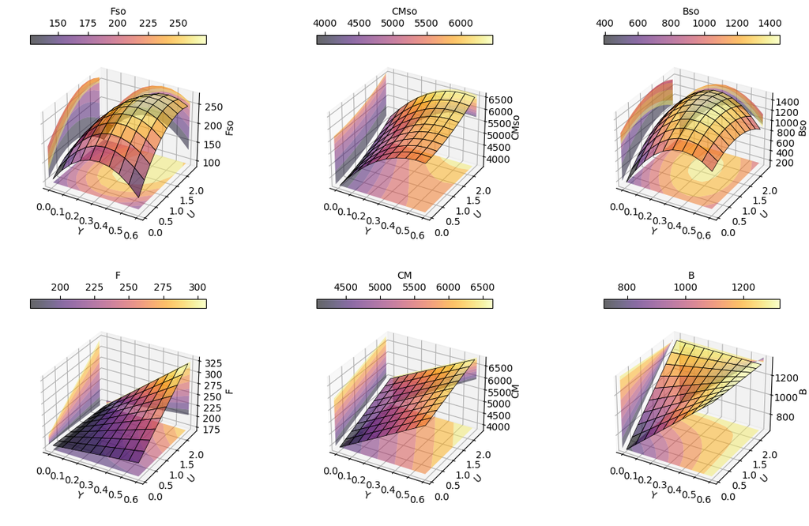

```python
fig, ax = plt.subplots(2,3, figsize=(15,9),subplot_kw={"projection": "3d"})
ax = ax.flatten()

for i,(key,val) in enumerate(fm_ccd.functions.items()):
    plot_surface(x='Y', y='U', z=key,
         model=fm_ccd,
         n_pts=10,
         ax=ax[i],
         other_params=dict(),
         labels=dict(xlabel='Y', ylabel='U', zlabel=key), cmap='inferno', scaled=True)
```

# Optimization Using Desirabilty Function

A desirability function $D$ is used to optimize the two independe variables at same time.

The function $d_i$ was defined as

```python
@latexify.with_latex
def d_i(Y, Ymin=Ymin, Ymax=Ymax, r=1):
    if Y <= Ymin:
        return 0
    elif Y > Ymin and Y < Ymax:
        return ((Y-Ymin)/(Ymax-Ymin))**r
    else:
        return 1

d_i
```

$$ \displaystyle \mathrm{d_i}(Y, Ymin, Ymax, r) = \left\{ \begin{array}{ll} {0}, & \mathrm{if} \ {Y \le Ymin} \\ \left( \frac{Y - Ymin}{Ymax - Ymin} \right)^{r}, & \mathrm{if} \ {{Y > Ymin} \land {Y < Ymax}} \\ {1}, & \mathrm{otherwise} \end{array} \right. $$

```python
from scipy.optimize import minimize
import latexify

responses = ['Fso','CMso','Bso']
model = fm_ccd
Ymax = 7000
Ymin = 200


def D(independent_vars):
    d_list = []
    for Yi in responses:
        d_list.append( d_i(model[Yi].predict(dict(U=independent_vars[0],Y=independent_vars[1]))[0]) )
    d_array = np.array(d_list)
    n = len(d_array)
    return 1-(np.prod(d_array)**(1/n))


from scipy import optimize as opt

x0 = (0, 0)
bounds = [(-1.41,1.41),(-1.41,1.41)]

optimum = minimize(D, x0, method='SLSQP', bounds=bounds)
optimum
```

```
 message: Optimization terminated successfully
 success: True
  status: 0
     fun: 0.8802039525109903
       x: [ 6.344e-01  4.816e-01]
     nit: 10
     jac: [ 1.291e-04  2.973e-05]
    nfev: 30
    njev: 10
```

# Anova table and lack of fit

To check model validity an ANOVA test and lack of fit can be used.

```python
fm_ccd.anova('Fso')
```

|  | df | sum_sq | mean_sq | F | PR(>F) |
| --- | --- | --- | --- | --- | --- |
| U | 1.0 | 3099.522852 | 3099.522852 | 4.600914 | 0.084782 |
| Y | 1.0 | 7419.724833 | 7419.724833 | 11.013797 | 0.021038 |
| U:Y | 1.0 | 1056.250000 | 1056.250000 | 1.567891 | 0.265894 |
| np.power(U, 2) | 1.0 | 918.771390 | 918.771390 | 1.363819 | 0.295530 |
| np.power(Y, 2) | 1.0 | 7192.080882 | 7192.080882 | 10.675884 | 0.022263 |
| Residual | 5.0 | 3368.377315 | 673.675463 | NaN | NaN |

```python
fm_ccd.lack_of_fit('Fso', alpha=0.05)
```

|  | Source_of_Variation | df | sum_sq | mean_sq | F | F_table | p |
| --- | --- | --- | --- | --- | --- | --- | --- |
| 0 | Regression | 3.0 | 11575.497685 | 3858.499228 | 2.352901 | 4.346831 | 0.158352 |
| 1 | Residual | 7.0 | 11479.229588 | 1639.889941 | NaN | NaN | NaN |
| 2 | Lack_of_Fit | 5.0 | 11297.229588 | 2259.445918 | 24.829076 | 19.296410 | 0.039167 |
| 3 | Pure_Error | 2.0 | 182.000000 | 91.000000 | NaN | NaN | NaN |
| 4 | Total | 10.0 | 23054.727273 | NaN | NaN | NaN | NaN |

# Optmization Results

In the original papaer authors have found a desirability function of 0.87 and an optimum point at

$$ U=0.97\; g/L $$$$ Y=0.36\; g/L $$

The corresponding cellulase activities of

$$ F = 254\; U/L $$$$ C = 6383\; U/L $$$$ B = 1448\; U/L $$

$$ U=1.71\; g/L $$$$ Y=0.40\; g/L $$

This corresponts to a total cellulase activity of 8106 U/L, from which partial values for each metric are

$$ F = 245\; U/L $$$$ C = 6623\; U/L $$$$ B = 1238\; U/L $$

```python
fm_ccd.decode_variables(variables=dict(U=optimum.x[0], Y=optimum.x[1]))
```

```
{'U': 1.7069155936557219, 'Y': 0.39546634255213986}
```

```python
F=fm_ccd.predict(function='Fso', variables=fm_ccd.decode_variables(variables=dict(U=optimum.x[0], Y=optimum.x[1])))
F
```

```
0    244.92823
dtype: float64
```

```python
C=fm_ccd.predict(function='CMso', variables=fm_ccd.decode_variables(variables=dict(U=optimum.x[0], Y=optimum.x[1])))
C
```

```
0    6623.108285
dtype: float64
```

```python
B=fm_ccd.predict(function='Bso', variables=fm_ccd.decode_variables(variables=dict(U=optimum.x[0], Y=optimum.x[1])))
B
```

```
0    1238.00179
dtype: float64
```